# SME0803-LISTA2

Francisco Miranda

12/03/2020

# VISUALIZAÇÃO E EXPLORAÇÃO DE DADOS - LISTA 2

Prof. Juliana Cobre]

Todos os exercícios foram retirados de Stephen Kokoska - Introdução à Estatística - Uma Abordagem por Resolução de Problemas, exceto onde indicado.

## Exercicio 1

O gerente de vendas de uma concessionária de automóveis Chrysler enviou uma pesquisa a proprietários desses carros, selecionados aleatoriamente, para avaliar a satisfação do cliente. Uma das perguntas era “Qual a chance de você comprar outro carro da mesma marca e modelo?” Os participantes da pesquisa podiam responder Muito Provável (MP), Provável (P), Neutro (N), Im- provável (I) ou Muito Improvável (MI). Os resultados estão disponíveis no arquivo 2019-sme0803-lista2dadosK2.14.R.

- 1. Construa uma distribuição de frequência para esses dados.
- 2. Use a tabela da parte (a) para construir um gráfico de setores para esses dados.

```r
a <- read.delim("dados1.txt") #lendo os dados
a.freq <- table(a) #tabulando as frequencias

cbind(a.freq) #imprime a tabela
```

```
##    a.freq
## I       8
## MI     15
## MP      7
## N       7
## P      12
```

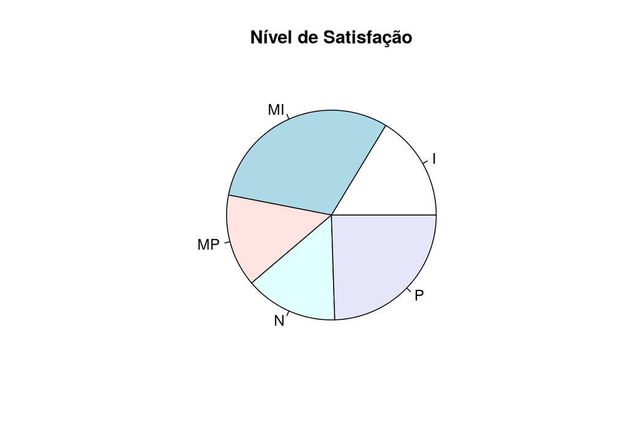

```r
names(a.freq) <- c("I","MI","MP","N","P") #rotulos
pct <- round(a.freq/sum(a.freq)*100) #calcula percentuais

pie(a.freq, labels = names(a.freq),  main="Nível de Satisfação")
```

## Exercício 2

Obteve-se uma amostra aleatória de eleitores em uma eleição para substituir um senados do estado que se apresentava por motivos de saúde. A filiação partidária de cada eleitor é apresentada no arquivo 2019-sme0803-lista2dadosK2.15.R: democrata (D), Republicano (R) ou Independente (I).

- 1. Construa uma distribuição de frequência para esses dados.
- 2. Use a tabela da parte (a) para construir um gráfico de setores para esses dados.

```r
  a <- read.delim("dados2.txt") #lendo os dados
  a.freq <- table(a) #tabulando
  names(a.freq) <- c("D","I","R")
  cbind(a.freq) #imprime a tabela
```

```
##   a.freq
## D     23
## I     18
## R     18
```

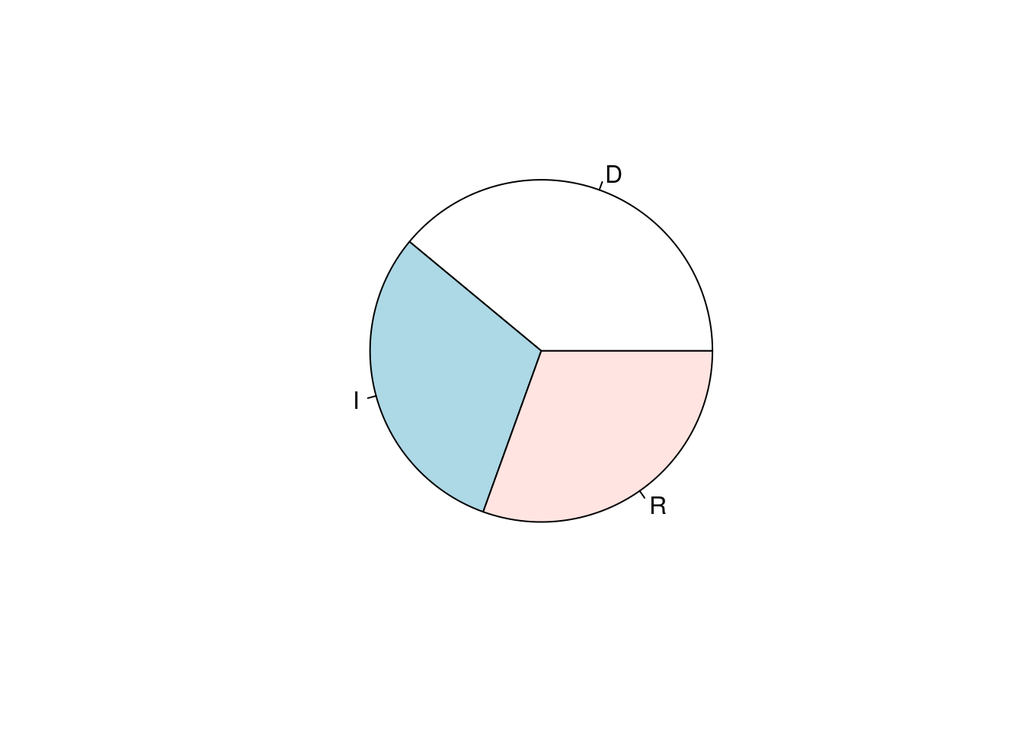

```r
  pie(a.freq, names(a.freq))
```

## Exercício 3

A distribuição de conceitos em uma grande turma de psicologia na Lousiania State University é apresentada no arquivo 2019-sme0803-lista2dadosK2.17.R.

- 1. Ache a frequência relativa para cada conceito.
- 2. Construa um gráfico de barras, usando a frequência no eixo vertical, e um gráfico de setores a partir da distribuição de frequência.
- 3. Quantos estudantes havia nessa turma de psicologia? Qual proporção de estudantes foi aprovada (ou seja, recebeu D ou mais)?

```r
  a <- c(10, 43, 54, 26, 15)
  names(a) <- c("A","B","C","D","E")
  a.freq <- a/sum(a)
  cbind(a.freq)
```

```
##       a.freq
## A 0.06756757
## B 0.29054054
## C 0.36486486
## D 0.17567568
## E 0.10135135
```

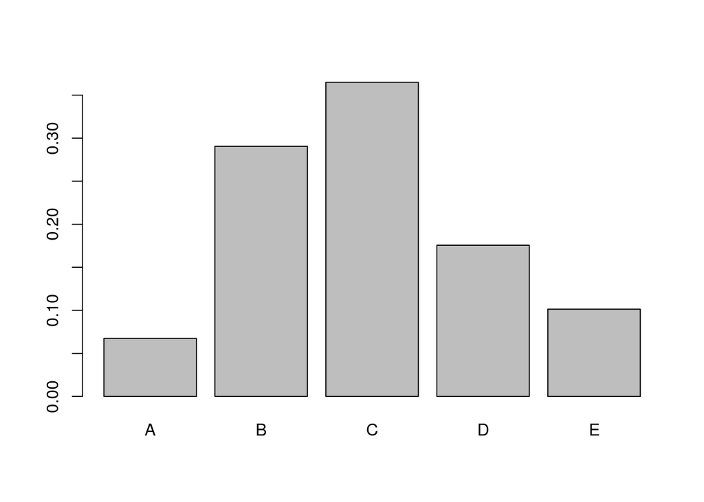

```r
  barplot(a.freq)
```

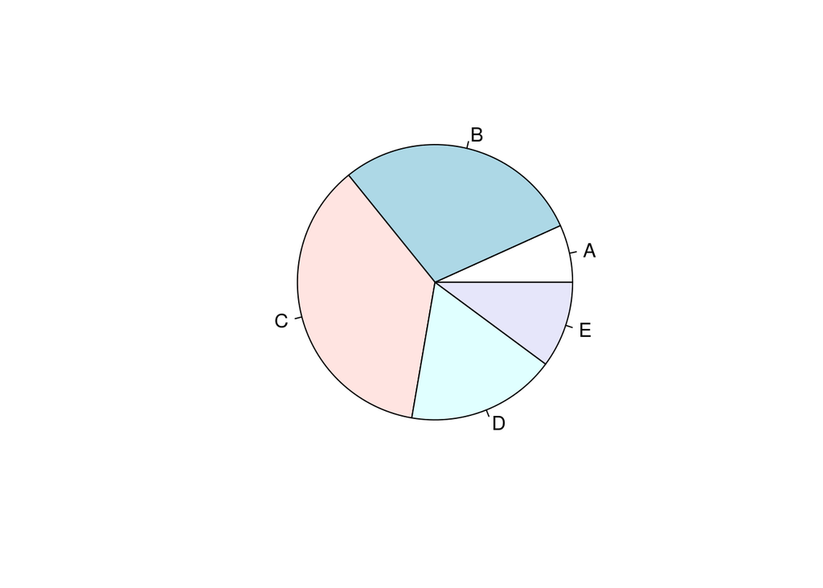

```r
  pie(a.freq,labels = names(a))
```

```r
  print(c("Estudantes na turma:",sum(a)))
```

```
## [1] "Estudantes na turma:" "148"
```

```r
  print(c("Estudantes aprovados:",sum(a)-a[length(a)]))
```

```
##                                               E
## "Estudantes aprovados:"                   "133"
```

## Exercicio 4

Obteve-se uma amostra aleatória de assinantes antigos de Popular Woodworking e perguntou-se a cada um a marca de serra de mesa que usava. Os resultados são apresentados no arquivo 2019-sme0803-lista2dadosK2.19.R.

- 1. Construa uma distribuição de frequência para esses dados.
- 2. Esboce cuidadosamente um gráfico de barras, usando a frequência no eixo vertical, e um gráfico de setores para esses dados.
- 3. Qual proporção de pessoas nessa amostra usa uma serra de mesa Craftsman ou Black & Decker?
- 4. Qual proporção de pessoas nessa amostra não usa uma serra de mesa Delta?

```r
  a <- read.delim("dados4.txt") #lendo os dados
  a.freq <- table(a)
  cbind(a.freq) #tabela de frequencia
```

```
##                a.freq
## Black & Decker      4
## Craftsman           5
## Delta               6
## DeWalt              6
## Makita              6
```

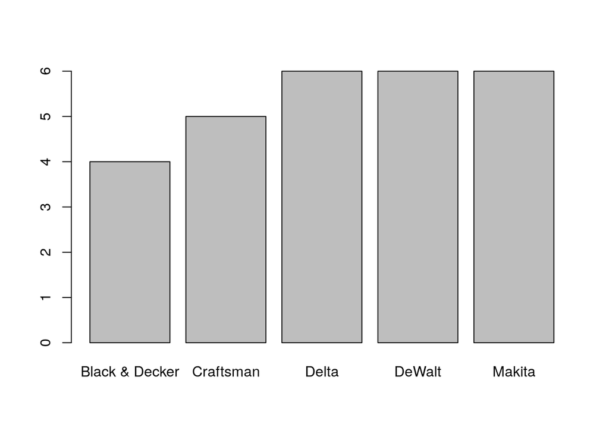

```r
  barplot(a.freq) #grafico de barras
```

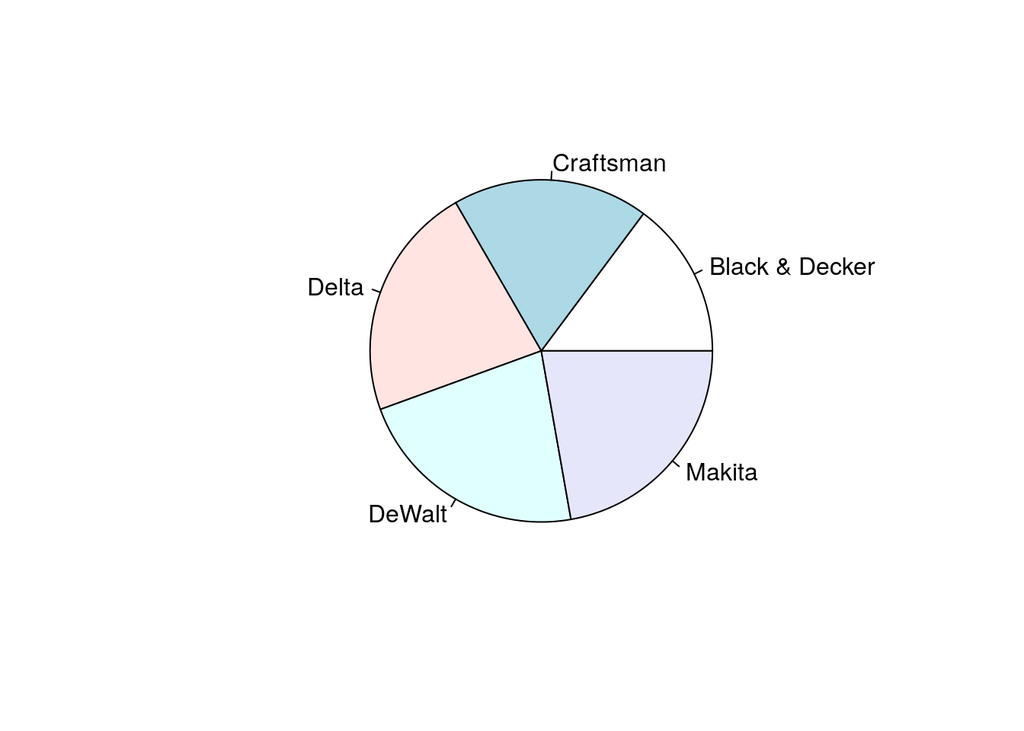

```r
  pie(a.freq) #grafico de setores
```

```r
  pct <-round(a.freq/sum(a.freq)*100)
  print(c("% Craftsman ou Black & Decker:",pct["Craftsman"] +pct["Black & Decker"]))
```

```
##                                                         Craftsman
## "% Craftsman ou Black & Decker:"                             "34"
```

```r
  print(c("% Não usa Delta:", (100-pct["Delta"])))
```

```
##                                 Delta
## "% Não usa Delta:"               "78"
```

## Exercício 5

Os cintos de segurança de um automóvel é projetado para evitar que um ocupante entre em contato com o interior do carro e que seja ejetado para fora dele durante um acidente. Os cintos de segurança dianteiros tornaram-se equipamentos obrigatórios em 1964, e os traseiros em 1968. A Administração de Segurança do Tráfego nas Estradas estuda várias características relativas a mortes de passageiros de veículos. A tabela, encontrada no arquivo 2019-sme0803-lista2dadosK2.30.xls, mostra as mortes de ocupantes de veículos, com 16 anos de idade ou mais, em acidentes de carro em 2006 por hora do dia e uso do cinto.

- 1. Ache a frequência relativa para a categoria com cinto para cada hora do dia. Construa um gráfico de barras, usando a frequência no eixo vertical (e hora do dia no eixo horizontal).
- 2. Ache a frequência relativa para a categoria sem cinto para cada hora do dia. Construa um gráfico de barras, usando a frequência no eixo vertical (e hora do dia no eixo horizontal).
- 3. Como se comparam esses dois gráficos de barras? Descreva quaisquer semelhanças ou diferenças.

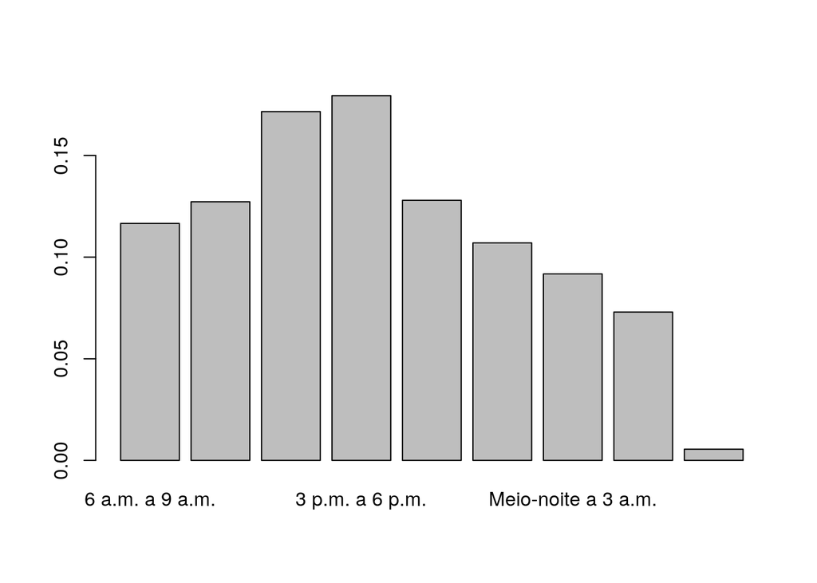

```r
#install.packages("readxl")
library(readxl) #pacote para ler arquivos xls.
tab <-  read_excel("SME0803_dados/2019-sme0803-lista2dadosK2.30.xls")

na <- sum(tab$`Com cinto`)
freqa <- tab$`Com cinto` / na
names(freqa) <- tab$Hora
barplot(freqa)
```

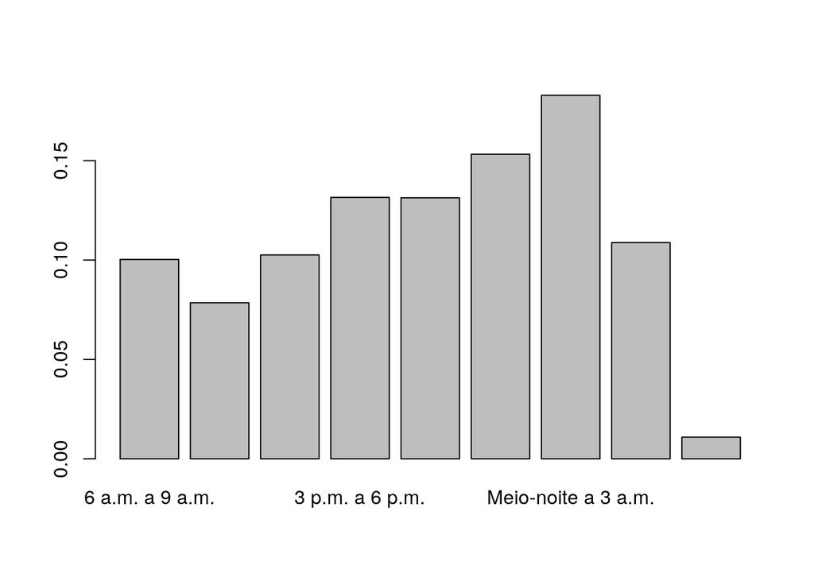

```r
nb <- sum(tab$`Sem cinto`)
freqb <- tab$`Sem cinto` / nb
names(freqb) <- tab$Hora
barplot(freqb)
```

#### Resp c: Os dados parecer ter distribuição normal, porém seria necessário um teste de aderência (tentar ks.test(dados.ex14_6,y=“pnorm”,mean=10,sd=5) ) para comprovar essa hipótese. As frequencias tem uma distribuição similar entre si, sendo a média dos acidentes com cinto durante a tarde, enquanto os acidentes sem cinto ocorrem em média durante a madrugada.

## Exercício 6

Gráficos de barras empilhados ou lado a lado podem ser usados para a comparação de dados categóricos obtidos de duas (ou mais) fontes ou grupos diferentes. Os dados, disponíveis no arquivo 2019-sme0803-lista2dadosK2.33.xls, apresentam uma os conceitos de testes em duas seções diferentes de alunos de um curbso introdutório de estatística. Construa gráficos de barras empilhadas e lado a lado para esses dados.

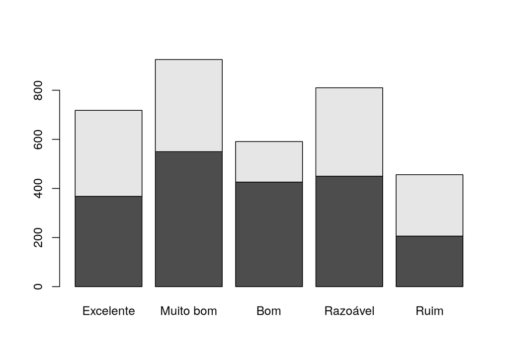

```r
library(readxl)
tab <-  (read_excel("SME0803_dados/2019-sme0803-lista2dadosK2.33.xls"))
nomes <- tab$Classificação
tab <- matrix(c(tab$`Freq Homens`,tab$`Freq Mulheres`),ncol = 2, nrow = 5)
rownames(tab) <- nomes
colnames(tab) <- c("Freq. Homens", "Freq Mulheres")
barplot(t(tab))
```

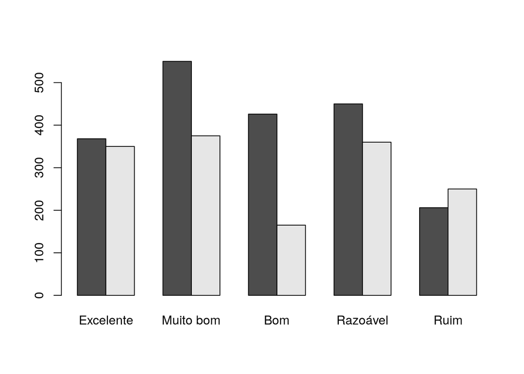

```r
barplot(t(tab), beside = TRUE)
```

## Exercício 7

O número de mulheres na força de trabalho tem crescido continuamente desde 1970. Em 2007, havia aproximadamente 71 milhões de mulheres trabalhadoras com 16 anos de idade ou mais, representando 59% de toda a força de trabalho dos Estados Unidos. A tabela disponível no arquivo 2019-sme0803-lista2dadosK2.34.xls apresenta a frequência relativa de trabalhadores homens e mulheres, por idade, em 2007.

- 1. Construa um gráfico de barras lado a lado, usando a frequência relativa de cada classe.
- 2. Usando esses dados, há alguma maneira de se determinar a frequência relativa de todas as mulheres (ou homens), com 16 anos de idade ou mais, que estavam trabalhando em 2007? Por que ou por que não?

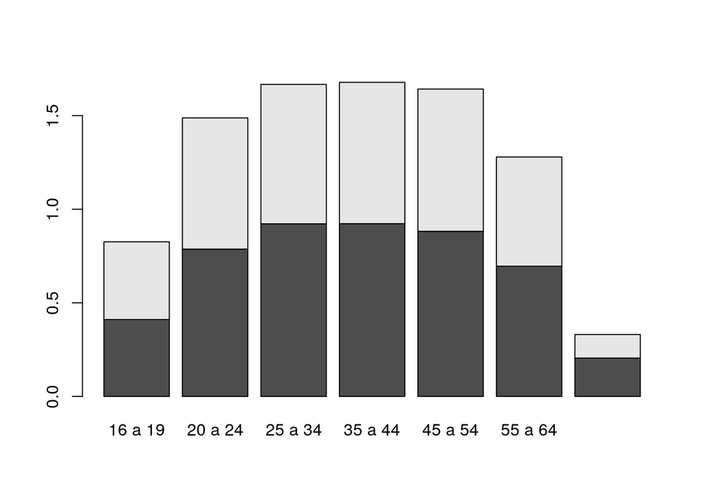

```r
library(readxl)

tab <-  read_excel("SME0803_dados/2019-sme0803-lista2dadosK2.34.xls")
nomes <- tab$`Grupo de idade`
tab <- matrix(c(tab$`Freq. Relativa Homens`,tab$`Freq. Relativa Mulheres`),ncol = 2, nrow = 7)
rownames(tab) <- nomes
colnames(tab) <- c("Freq. Relativa Homens", "Freq Relativa Mulheres")
barplot(t(tab))
```

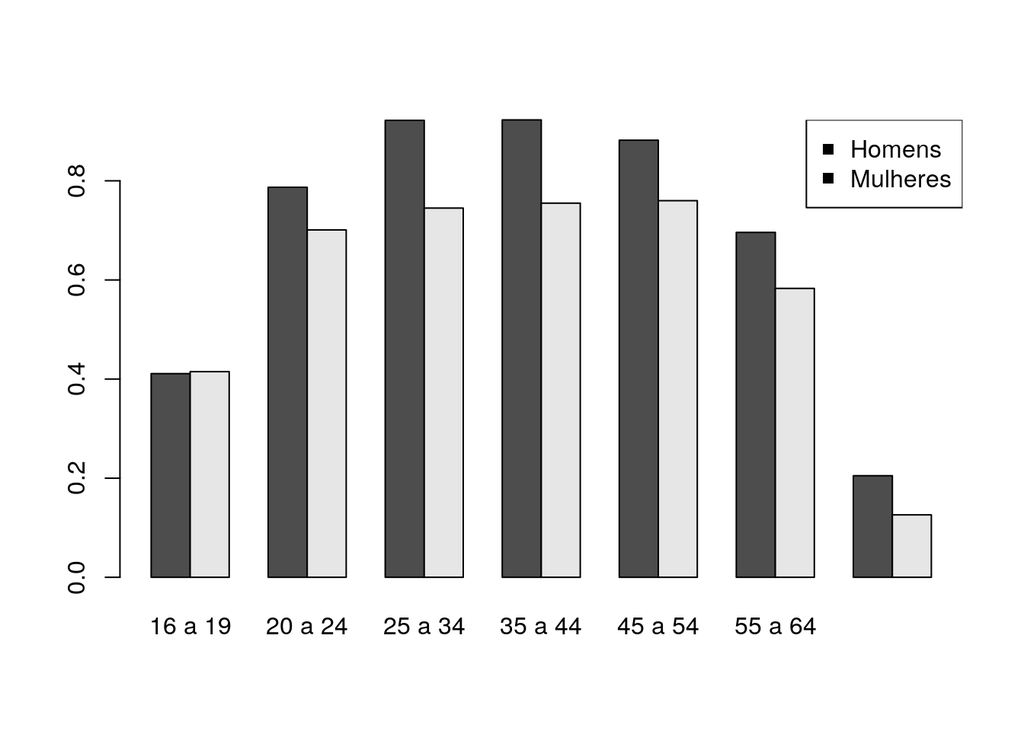

```r
barplot(t(tab), beside = TRUE)
legend("topright",
       legend = c("Homens","Mulheres"),
       pch = 15)
```

## Exercício 8

Considere os dados disponíveis no arquivo 2019-sme0803-lista2dadosK2.53.xls. Construa uma distribuição de frequência para resumir esses dados, usando os intervalos de classe 78-80, 80-82, 82-84, . . .

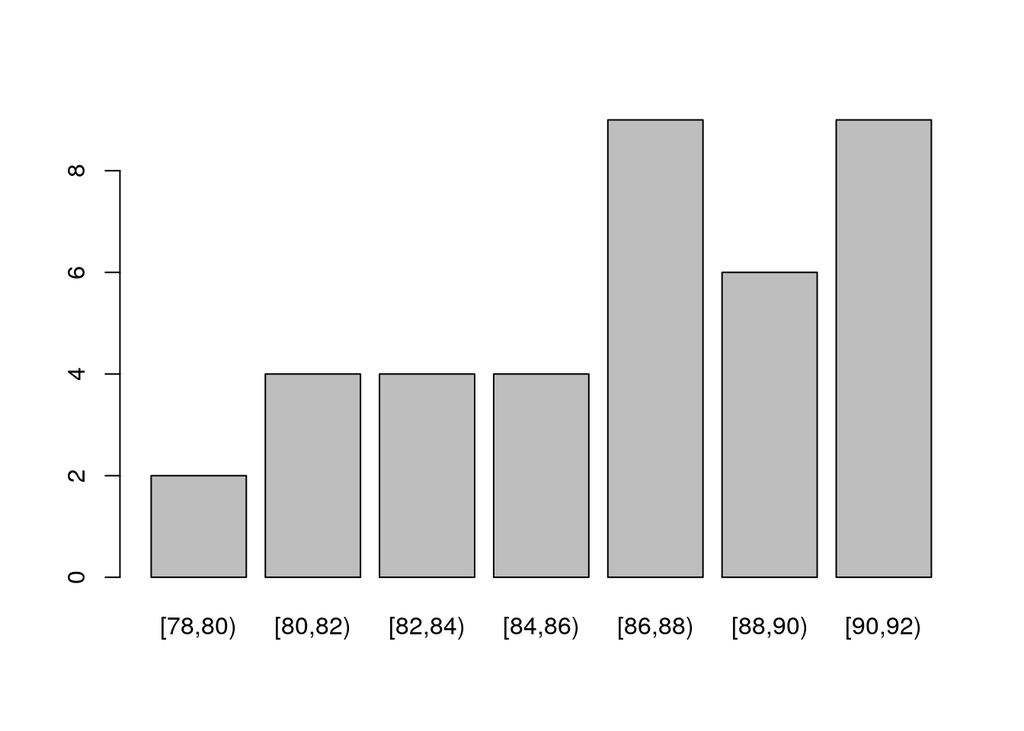

```r
library(readxl)

tab <-  read_excel("SME0803_dados/2019-sme0803-lista2dadosK2.53.xls")

dados <- sort(tab$Dados)
n = length(dados)
A = max(dados) - min(dados)
A_c = 2

limites = seq(min(dados),max(dados),A_c)

freq = table(cut(dados, breaks = limites, right = FALSE))
barplot(freq)
```

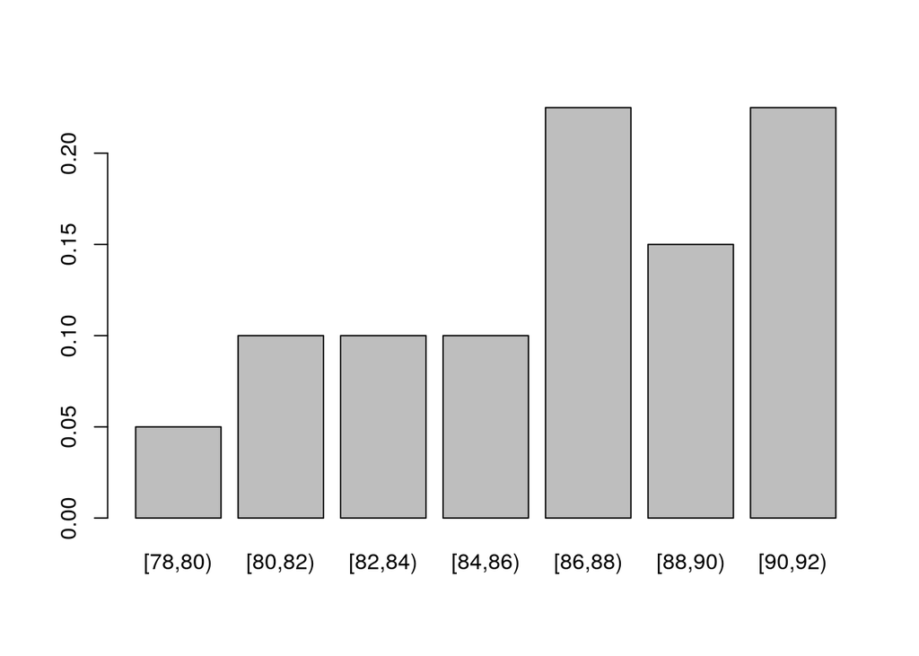

```r
freq_r = freq/n
barplot(freq_r)
```

## Exercicio 9

Histograma de frequencia dos dados da tabela

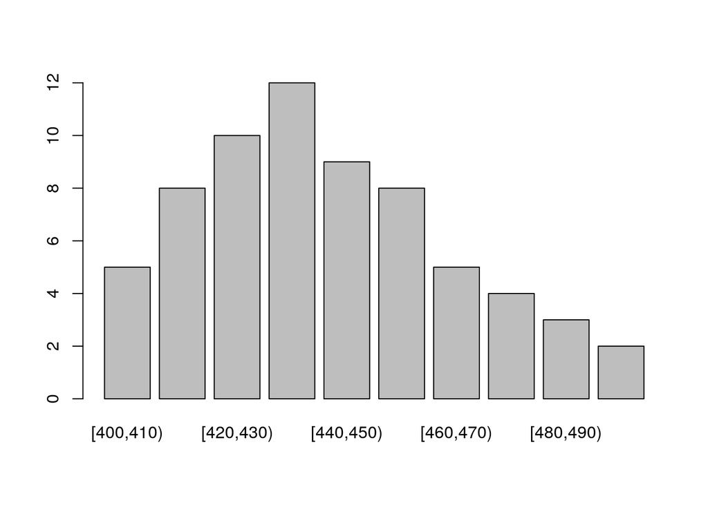

```r
freq <- c(5,8,10,12,9,8,5,4,3,2)
limites <- seq(400,500,10)
classes = levels(cut(freq, breaks = limites, right = FALSE))
names(freq) <- classes

barplot(freq)
```

## Exercicio 13

Há padrões naciinais para cada sinal em estradas, marcação de solo e sinal de traáfego. Embora a lei estadual prevaleça, não há uma política estadual sobre o tempo de duração da luz amarela. Suponha que a duração recomentada em nível federal seja de 3 a 6 segundos, com tempos mais longos em vias com limites mais altos de velocidade. Seliecinou-se uma amostra aleatória de sinais de tráfego em Norman, Oklahoma, e registrou-se o tempo de duração da luz amarela para cada um deles. sme0803-lista2dadosK2.52.xls.

- Contrua um histograma de ramo-e-folhas. Divida cada ramo em cinco partes.
- com base no diagrama da parte a, voce acha que a duração da luz amarela nessa cidade satisfaz a recomendação federal? justifique sua resposta.

```r
tab <-  read_excel("SME0803_dados/2019-sme0803-lista2dadosK2.52.xls")
stem(tab$Duração, scale = 2)
```

```
##
##   The decimal point is 1 digit(s) to the left of the |
##
##   34 | 0
##   36 | 00
##   38 | 00000000
##   40 | 000000
##   42 | 00000000
##   44 | 0000000000000
##   46 | 000000000000
##   48 | 000
##   50 | 000
##   52 | 00
##   54 |
##   56 | 00
```